# MEML_HW08

**Machine Learning for Mechanical Engineering**  
**Homework 08**  
**Due Thursday, 05/13/2021, 9:30 AM**

TA: Jongmok Lee  
Instructor: Prof. Seungchul Lee  
http://iai.postech.ac.kr/  
Industrial AI Lab at POSTECH

- For your handwritten solution, scan or take a picture of them.
- For your code, only .ipynb file will be graded.
  - Please write your NAME and student ID on your .ipynb files. ex) JongmokLee_20212781_HW07.ipynb
- Please compress all files to make a single .zip file
  - Please write your NAME and student ID on your .zip files. ex) JongmokLee_20212781_HW07.zip
  - Submit it to PLMS
- Do not submit a printed version of your code. It will not be graded.

# Problem 1

We would like to use the FDA (LDA) to classify digit 0 and digit 1

| Data | Data dexcription |
| --- | --- |
| 0 | 1000 images (28×28 pixels) of handwritten digit 0 |
| 1 | 1000 images (28×28 pixels) of handwritten digit 1 |

[Download data](https://www.dropbox.com/s/88x48w946kgjn1q/FDA_data.pkl?dl=1)

To read the files in Python, use the following code:

```python
import numpy as np
import matplotlib.pyplot as plt
from six.moves import cPickle

data = cPickle.load(open('./data_files/FDA_data.pkl', 'rb'))
data0 = data['0']
data1 = data['1']
```

1) Convert each of the pixels in 28 $\times$ 28 matrix to a binary value.

```python
## your code here
#
```

2) Extract features and plot the feature space. Now we must select the own ‘features’ from image data to detect digit 0 and digit 1. Two features are recommended

- (feature 1) The total average pixels located at the center of the image (`img[10:20,10:20]`).
- (feature 2) The total average pixels over the entire location.

$$\Phi(x) = \begin{bmatrix}\ \text{feature1}\\ \text{feature2} \end{bmatrix}$$

You should end up with a $2000\times2$ input matrix with the first $1000$ rows correspond to all of the ‘`data0`’ and the second 1000 rows correspond to the two features for all of the given ‘`data1`’.

```python
## your code here
#
```

```python
## your code here
#
```

3) Solve the problem with the FDA (LDA) and visualize the histogram of data on the projection line by class.

```python
## your code here
#
```

4) plot projection line and classification line in feature space.

```python
## your code here
#
```

# Problem 2

Consider the following matrix:

$$ \begin{align*} A = \begin{bmatrix} -1 & 1 & 0 \\ 0 & -1 & 1 \\ \end{bmatrix} \end{align*} $$

(a) Compute the Singular Value Decomposition (SVD) of matrix $A$ using python.

```python
## your code here
#
```

(b) In this time, solve it with your own hand (i.e, Compute SVD by hands).

(c) Compute the rank 1 approximation of matrix $A$ by hands.

# Problem 3

The data provided in this problem is a set of sequential pictures (or frames) taken from a video of people walking. The total number of pictures is 20. In this problem, you are asked to get rid of people in the pictures and only extract background from pictures.

[Download and unzip data](https://www.dropbox.com/s/eghi111f2j1wff2/capimage.zip?dl=1)

(a) Plot 'capimage_0.jpg' image in grayscale.

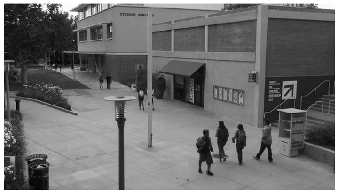

```
(338, 600)
```

```python
import numpy as np
import cv2
import matplotlib.pyplot as plt
%matplotlib inline

## your code here
#
```

(b) Load the image into grayscale and reshape each picture as (row $\times$ col, 1), then horizontally stack them to form matrix $A$ with a shape of (row $\times$ col, 20).

```python
## your code here
#
```

(c) Compute SVD of matrix $A$ and plot the sigular values.

[output not shown]

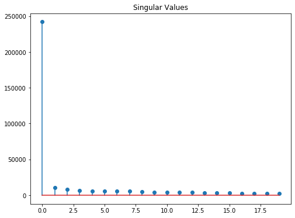

```python
## your code here
#
```

(d) Apply low rank approximation to matrix $A$ with $k=1$, and then plot $\hat A[:,0]$ with a reshape of (row, col).

$$\hat A = U_k \Sigma_k V_k^T = \sum_{i=1}^{k}\sigma_i u_i v_i^T \qquad (k = 1)$$

[figure not shown]

```python
## your code here
#
```

(e) Explain why we have the above result.